# Iris Data Analysis

Charles Gonzalez-Dyer

## Setting Up My Environment

First I will load the needed packages and ensure that the data set was imported properly with the View() function.

```r
install.packages("skimr")
library(skimr)
install.packages("caret")
library(caret)
library(datasets)
library(dplyr)
data("iris")
View(iris)
```

This data set contains measurements of iris flowers. To help me get a better idea of each variable in the data frame, I can use summary(*) and skim(*) to view general descriptive statistics.

```r
summary(iris)
```

```
##   Sepal.Length    Sepal.Width     Petal.Length    Petal.Width
##  Min.   :4.300   Min.   :2.000   Min.   :1.000   Min.   :0.100
##  1st Qu.:5.100   1st Qu.:2.800   1st Qu.:1.600   1st Qu.:0.300
##  Median :5.800   Median :3.000   Median :4.350   Median :1.300
##  Mean   :5.843   Mean   :3.057   Mean   :3.758   Mean   :1.199
##  3rd Qu.:6.400   3rd Qu.:3.300   3rd Qu.:5.100   3rd Qu.:1.800
##  Max.   :7.900   Max.   :4.400   Max.   :6.900   Max.   :2.500
##        Species
##  setosa    :50
##  versicolor:50
##  virginica :50
##
##
##
```

```r
skim(iris)
```

Data summary

| Name | iris |
| --- | --- |
| Number of rows | 150 |
| Number of columns | 5 |
| _______________________ |  |
| Column type frequency: |  |
| factor | 1 |
| numeric | 4 |
| ________________________ |  |
| Group variables | None |

**Variable type: factor**

| skim_variable | n_missing | complete_rate | ordered | n_unique | top_counts |
| --- | --- | --- | --- | --- | --- |
| Species | 0 | 1 | FALSE | 3 | set: 50, ver: 50, vir: 50 |

**Variable type: numeric**

| skim_variable | n_missing | complete_rate | mean | sd | p0 | p25 | p50 | p75 | p100 | hist |
| --- | --- | --- | --- | --- | --- | --- | --- | --- | --- | --- |
| Sepal.Length | 0 | 1 | 5.84 | 0.83 | 4.3 | 5.1 | 5.80 | 6.4 | 7.9 | ▆▇▇▅▂ |
| Sepal.Width | 0 | 1 | 3.06 | 0.44 | 2.0 | 2.8 | 3.00 | 3.3 | 4.4 | ▁▆▇▂▁ |
| Petal.Length | 0 | 1 | 3.76 | 1.77 | 1.0 | 1.6 | 4.35 | 5.1 | 6.9 | ▇▁▆▇▂ |
| Petal.Width | 0 | 1 | 1.20 | 0.76 | 0.1 | 0.3 | 1.30 | 1.8 | 2.5 | ▇▁▇▅▃ |

I will also check for null values.

```r
sum(is.na(iris))
```

```
## [1] 0
```

Since there are no null values, I can proceed without needing to clean the data.

# Data Exploration

The first thing that I will want to investigate are the differences between the three different species of iris flower. To begin this process, I will create a pipeline to group the different species of flower before I skim().

```r
iris %>%
  dplyr::group_by(Species) %>%
  skim()
```

Data summary

| Name | Piped data |
| --- | --- |
| Number of rows | 150 |
| Number of columns | 5 |
| _______________________ |  |
| Column type frequency: |  |
| numeric | 4 |
| ________________________ |  |
| Group variables | Species |

**Variable type: numeric**

| skim_variable | Species | n_missing | complete_rate | mean | sd | p0 | p25 | p50 | p75 | p100 | hist |
| --- | --- | --- | --- | --- | --- | --- | --- | --- | --- | --- | --- |
| Sepal.Length | setosa | 0 | 1 | 5.01 | 0.35 | 4.3 | 4.80 | 5.00 | 5.20 | 5.8 | ▃▃▇▅▁ |
| Sepal.Length | versicolor | 0 | 1 | 5.94 | 0.52 | 4.9 | 5.60 | 5.90 | 6.30 | 7.0 | ▂▇▆▃▃ |
| Sepal.Length | virginica | 0 | 1 | 6.59 | 0.64 | 4.9 | 6.23 | 6.50 | 6.90 | 7.9 | ▁▃▇▃▂ |
| Sepal.Width | setosa | 0 | 1 | 3.43 | 0.38 | 2.3 | 3.20 | 3.40 | 3.68 | 4.4 | ▁▃▇▅▂ |
| Sepal.Width | versicolor | 0 | 1 | 2.77 | 0.31 | 2.0 | 2.52 | 2.80 | 3.00 | 3.4 | ▁▅▆▇▂ |
| Sepal.Width | virginica | 0 | 1 | 2.97 | 0.32 | 2.2 | 2.80 | 3.00 | 3.18 | 3.8 | ▂▆▇▅▁ |
| Petal.Length | setosa | 0 | 1 | 1.46 | 0.17 | 1.0 | 1.40 | 1.50 | 1.58 | 1.9 | ▁▃▇▃▁ |
| Petal.Length | versicolor | 0 | 1 | 4.26 | 0.47 | 3.0 | 4.00 | 4.35 | 4.60 | 5.1 | ▂▂▇▇▆ |
| Petal.Length | virginica | 0 | 1 | 5.55 | 0.55 | 4.5 | 5.10 | 5.55 | 5.88 | 6.9 | ▃▇▇▃▂ |
| Petal.Width | setosa | 0 | 1 | 0.25 | 0.11 | 0.1 | 0.20 | 0.20 | 0.30 | 0.6 | ▇▂▂▁▁ |
| Petal.Width | versicolor | 0 | 1 | 1.33 | 0.20 | 1.0 | 1.20 | 1.30 | 1.50 | 1.8 | ▅▇▃▆▁ |
| Petal.Width | virginica | 0 | 1 | 2.03 | 0.27 | 1.4 | 1.80 | 2.00 | 2.30 | 2.5 | ▂▇▆▅▇ |

Since the output is a bit cluttered, I will filter down the results a bit.

```r
iris %>%
  select(Sepal.Length, Sepal.Width, Species) %>%
  dplyr::group_by(Species) %>%
  skim()
```

Data summary

| Name | Piped data |
| --- | --- |
| Number of rows | 150 |
| Number of columns | 3 |
| _______________________ |  |
| Column type frequency: |  |
| numeric | 2 |
| ________________________ |  |
| Group variables | Species |

**Variable type: numeric**

| skim_variable | Species | n_missing | complete_rate | mean | sd | p0 | p25 | p50 | p75 | p100 | hist |
| --- | --- | --- | --- | --- | --- | --- | --- | --- | --- | --- | --- |
| Sepal.Length | setosa | 0 | 1 | 5.01 | 0.35 | 4.3 | 4.80 | 5.0 | 5.20 | 5.8 | ▃▃▇▅▁ |
| Sepal.Length | versicolor | 0 | 1 | 5.94 | 0.52 | 4.9 | 5.60 | 5.9 | 6.30 | 7.0 | ▂▇▆▃▃ |
| Sepal.Length | virginica | 0 | 1 | 6.59 | 0.64 | 4.9 | 6.23 | 6.5 | 6.90 | 7.9 | ▁▃▇▃▂ |
| Sepal.Width | setosa | 0 | 1 | 3.43 | 0.38 | 2.3 | 3.20 | 3.4 | 3.68 | 4.4 | ▁▃▇▅▂ |
| Sepal.Width | versicolor | 0 | 1 | 2.77 | 0.31 | 2.0 | 2.52 | 2.8 | 3.00 | 3.4 | ▁▅▆▇▂ |
| Sepal.Width | virginica | 0 | 1 | 2.97 | 0.32 | 2.2 | 2.80 | 3.0 | 3.18 | 3.8 | ▂▆▇▅▁ |

To get a deeper understanding of the data I can create a basic scatter plot.

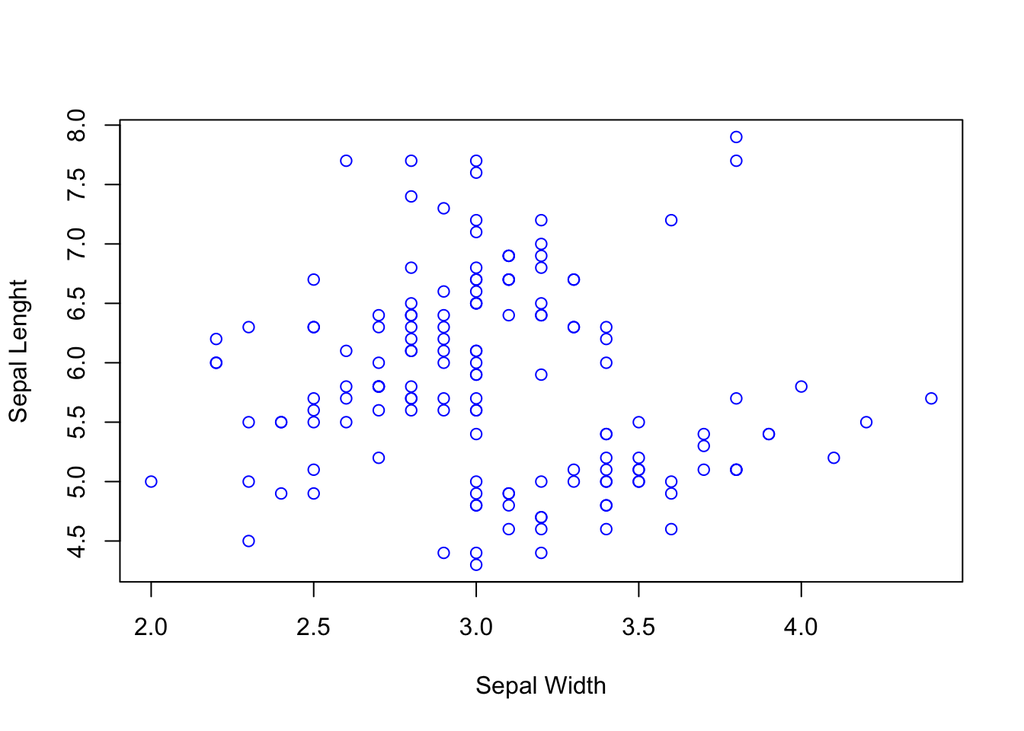

```r
plot(iris$Sepal.Width, iris$Sepal.Length, col="blue",
     xlab = "Sepal Width", ylab = "Sepal Lenght")
```

I can also create a histogram

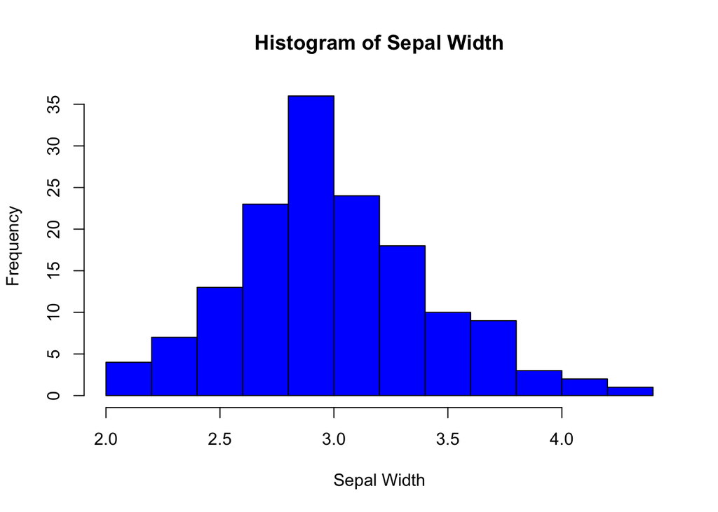

```r
hist(iris$Sepal.Width, col = "blue",
     main= "Histogram of Sepal Width",
     xlab= "Sepal Width")
```

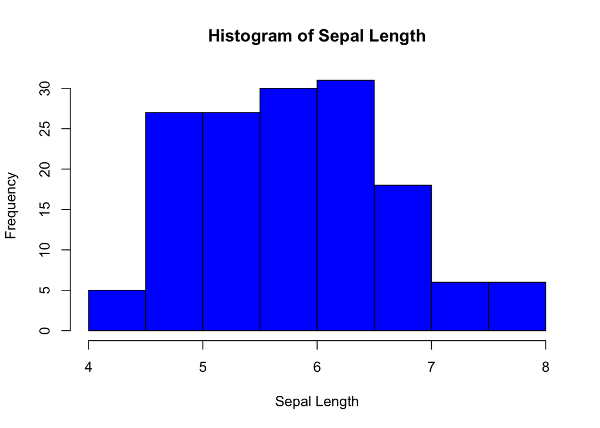

```r
hist(iris$Sepal.Length, col = "blue",
     main= "Histogram of Sepal Length",
      xlab= "Sepal Length")
```

or even a box plot of sepal lengths for each species

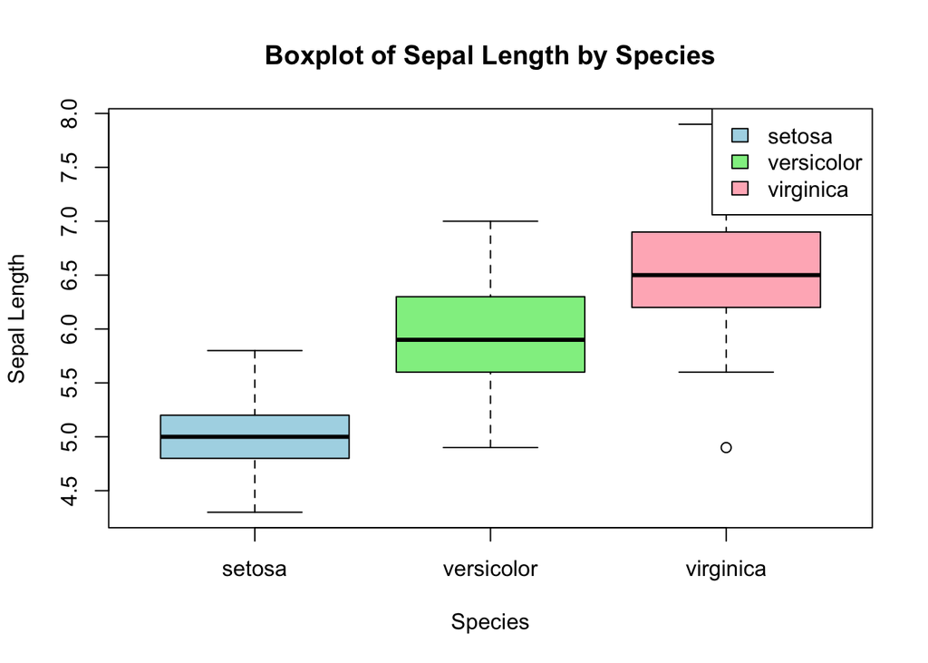

```r
boxplot(Sepal.Length ~ Species, data = iris,
        main = "Boxplot of Sepal Length by Species",
        xlab = "Species",
        ylab = "Sepal Length",
        col = c("lightblue", "lightgreen", "lightpink"))
legend("topright", legend = levels(iris$Species),
       fill = c("lightblue", "lightgreen", "lightpink"))
```

because of the numerous packages available for R there are even more ways to create similar plots!

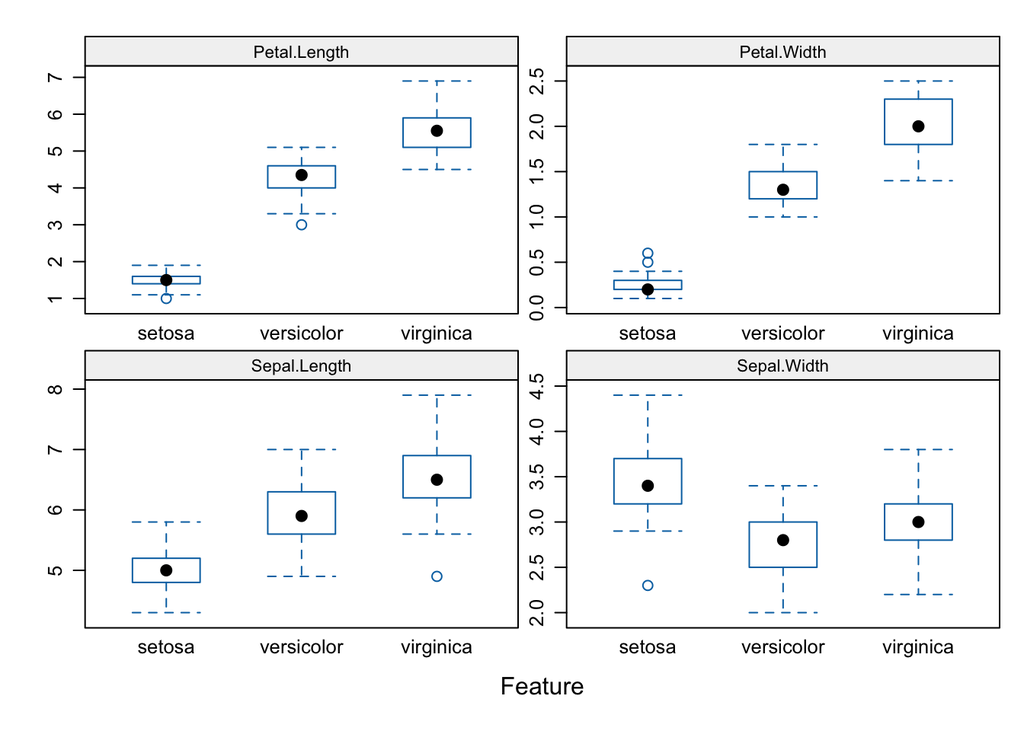

```r
featurePlot(x = iris[,1:4],
            y = iris$Species,
            plot = "box",
            strip=strip.custom(par.strip.text=list(cex=0.7)),
            scales = list(x = list(relation="free"),
                          y = list(relation= "free")))
```

## Statistical Analysis

After all of these descriptive statistics and visualizations it is time to run some statistical tests! I’ll start by determining if there is a statistically significant difference in the Sepal Length between the setosa and versicolor species. To start, I’ll create a new data frame that only contains the sepal lengths of setosa and versicolor.

```r
df1 <- iris %>%
  select(Sepal.Length, Species) %>%
  filter(Species == "setosa" |
          Species == "versicolor")
```

Having this new data frame will make running the t-test easier.

```r
t.test(data = df1, Sepal.Length ~ Species)
```

```
##
##  Welch Two Sample t-test
##
## data:  Sepal.Length by Species
## t = -10.521, df = 86.538, p-value < 2.2e-16
## alternative hypothesis: true difference in means between group setosa and group versicolor is not equal to 0
## 95 percent confidence interval:
##  -1.1057074 -0.7542926
## sample estimates:
##     mean in group setosa mean in group versicolor
##                    5.006                    5.936
```

The output shows that the p-value is < 2.2e-16, far less than 0.05. This indicates that the difference in sepal length *is* significantly different between the two groups. Lastly, I will create a linear regression model examining the relationship between sepal length and sepal width.

```r
summary(lm(Sepal.Width ~ Sepal.Length, data=iris))
```

```
##
## Call:
## lm(formula = Sepal.Width ~ Sepal.Length, data = iris)
##
## Residuals:
##     Min      1Q  Median      3Q     Max
## -1.1095 -0.2454 -0.0167  0.2763  1.3338
##
## Coefficients:
##              Estimate Std. Error t value Pr(>|t|)
## (Intercept)   3.41895    0.25356   13.48   <2e-16 ***
## Sepal.Length -0.06188    0.04297   -1.44    0.152
## ---
## Signif. codes:  0 '***' 0.001 '**' 0.01 '*' 0.05 '.' 0.1 ' ' 1
##
## Residual standard error: 0.4343 on 148 degrees of freedom
## Multiple R-squared:  0.01382,    Adjusted R-squared:  0.007159
## F-statistic: 2.074 on 1 and 148 DF,  p-value: 0.1519
```

In the above model the **response variable** is sepal width and the **predictor variable** is sepal length. The p-value of 0.152 indicates that there is not enough evidence to conclude a significant linear relationship between Sepal.Width and Sepal.Length.

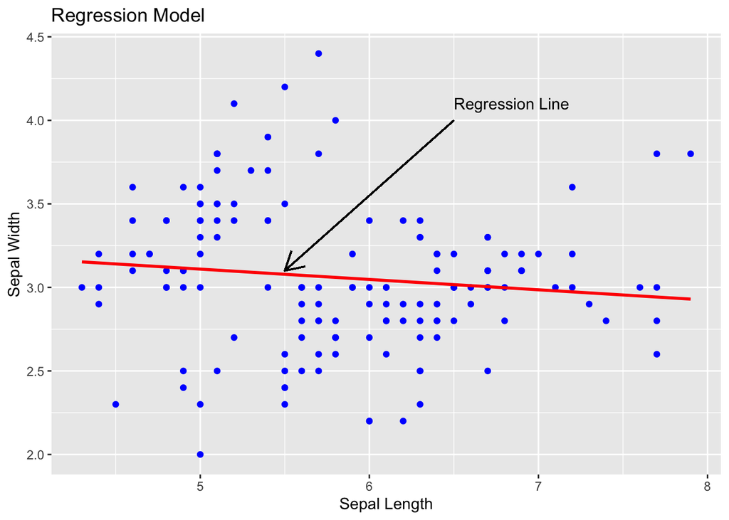

```r
ggplot(iris, aes(x = Sepal.Length, y = Sepal.Width)) +
  geom_point(color = "blue") +
  geom_smooth(method = "lm", se = FALSE, col = "red") +
  labs(x = "Sepal Length",
       y = "Sepal Width",
       title = "Regression Model")+
  geom_segment(aes(x = 6.5, y = 4.0, xend = 5.5, yend = 3.1),
               arrow = arrow(length = unit(0.2, "inches")),
               color = "black") +
  annotate("text", x = 6.5, y = 4.1, label = "Regression Line",
           color = "black", hjust = 0)
```